# Analysis of Prosper data

Jeff Ryu

September 17, 2017

### Analysis of Prosper data

I chose the Prosper loan data as my project because I wanted to try to replicate the interest rates charged to the borrowers by analyzing borrowers’ characteristics.

Before working on the predictive model, I wanted to get a better handle of the data, and also check if each row is a unique loan. Cross-checking the length of unique ‘ListingNumber’ versus the number of rows in the data, I found out there are duplicate rows. There are 113,066 unique ‘ListingNumber’ compared to 113,937 total rows (or around 0.8% had duplicate rows). There was 1 ‘ListingNumber’ of six duplicate rows, 4 with four duplicate rows, 32 with three duplicate rows and 790 with 2 duplicate rows.

Having checked the few of the duplicates, every columns of the duplicate rows were the same, except for the ‘ProsperScore’ column. I decided to remove the duplicate rows. Since I did not know which ‘ProsperScore’ is correct, I kept the one with highest. However, ‘ProsperScore’ will not be used in an analysis, since it’s bad data.

#### Monthly loan volume

Prosper data starts in November 2005 with a total monthly origination amount of about $50,000 (Chart A). Origination ramps up quickly and peaks near the $10 million on May 2008, before dropping to zero by November 2008 as the financial crisis halts lending activities. Lending starts again in May 2009 and ramps up quickly, especially in 2013. In January of 2014, lending peaks near $70 million. The data series end at March 2014 with $22 million. The sharp drop in March may be it may be an incomplete data set for the month.

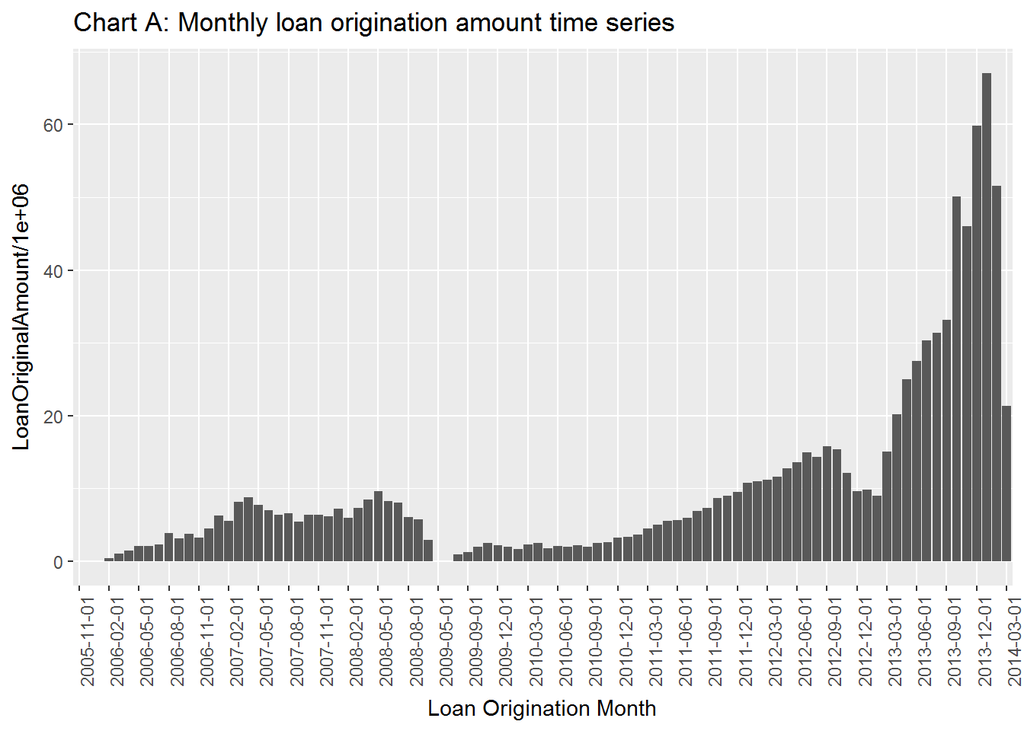

One thing I found out while researching about Prosper was that the lending process for Prosper changed from the auction model to fixed pricing in December 19, 2010 (http://www.lendacademy.com/prosper-com-ending-their-auction-process-dec-19th/)

With the change in the lending process, the interest rates borrowers were being charged will likely have changed as well. In the auction model, lenders were bidding the interest rate while Propser assigned the interest rate in the fixed pricing model. With the change in the lending, there were also changes in data available. For example, ‘CreditGrade’ variable was used in the auction based model compared to ‘ProsperRating..Alpha.’ after the change. The interest rate environment has also changed since pre- and post-financial crisis period. Due to these reasons, I decided to cut out data prior to January 2011.

#### Monthly borrower rates

- One explanation may be it was because benchmark interest rates have decreased during the period. However, this was not the case looking at the 3-year and 5-year Treasury rate on the St.Louis Fed’s FRED website (https://fred.stlouisfed.org/series/DGS5).
- Another possibility is that the spreads between lending rates and benchmark rates has tightened, leading to lower rates.
- It is also possible that the proportion of high quality borrowers in Prosper’s origination have increased during this period. Average borrower rates also declined from 20%-25% in the first half of 2012 to 15% in early 2014.
- It may also be that Prosper’s lending model was updated to result in lower lending rates rates due to competitions and/or positive return performances. If this is the case, the predictive model will result in some errors as the dependent variable is from two or more lending rate models.

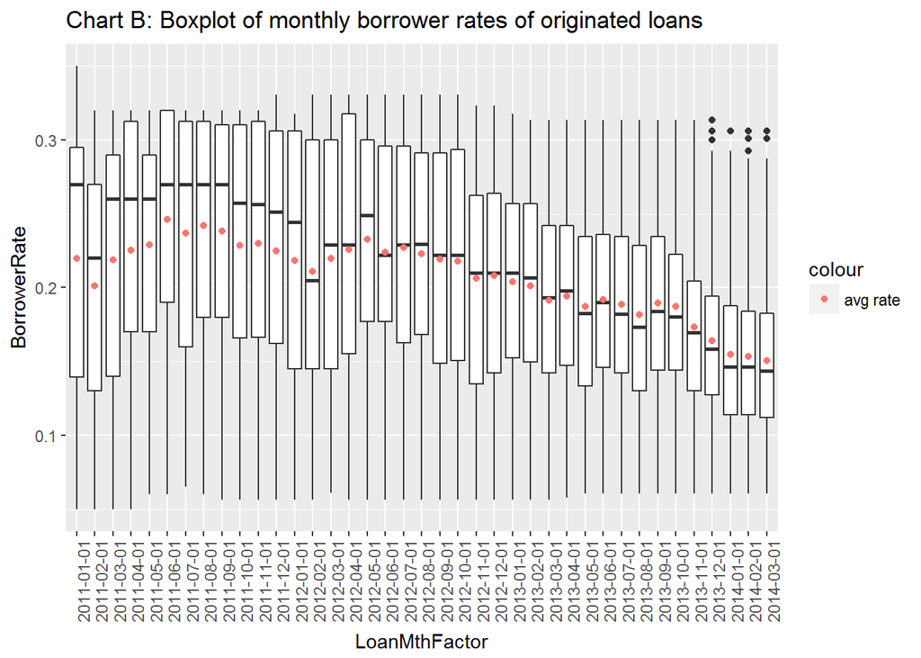

#### Prosper borrower rating vs borrower rate

While I will not use the Prosper borrower ratings in the predictive model given that this is a Prosper generated data, it may be useful to see how the borrower rates and Prosper rating relate. Prosper rating is in the following order with ‘AA’ being the best: ‘AA’, ‘A’, ‘B’, ‘C’, ‘D’, ‘E’, ‘HR’. Chart C shows the histogram of the ProsperRating. Two lowest counts are the extreme ratings of ‘AA’ and ‘HR’ at 4389 and 5804, respectively, while ‘C’ rated borrowers are highest at 17112.

```
##           A    AA     B     C     D     E    HR
##     0 12969  4389 14734 17112 12526  8893  5804
```

```
##    AA     A     B     C     D     E    HR
##  4389 12969 14734 17112 12526  8893  5804
```

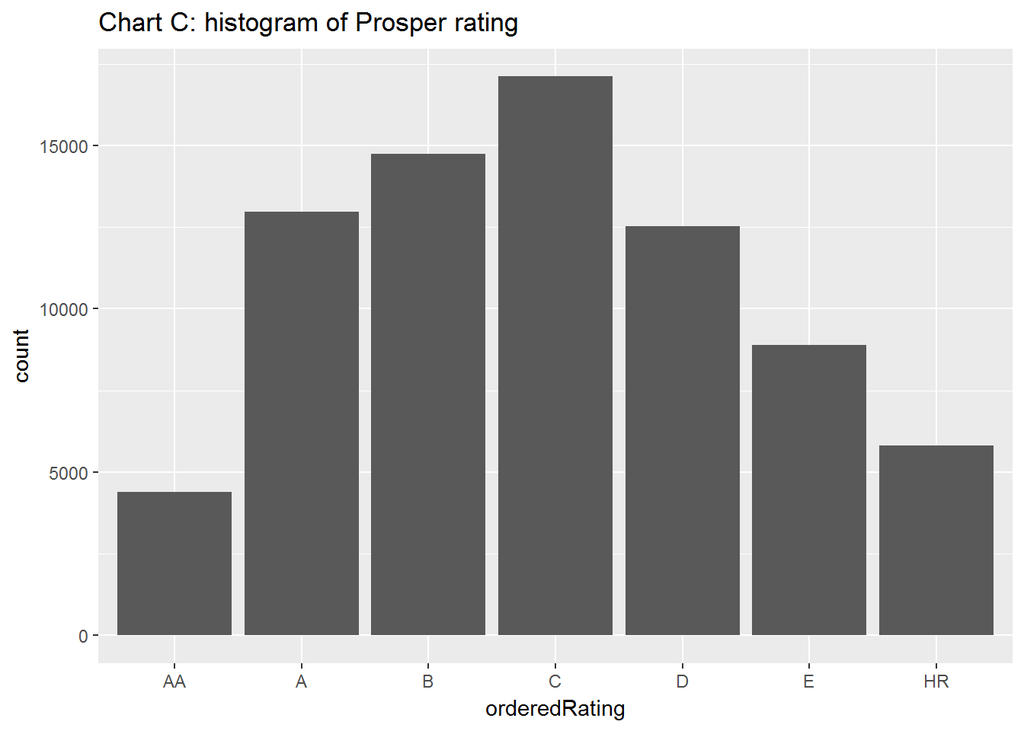

Chart D shows the boxplot of borrower rates for each ratings. As expected, borrower rate increases as rating worsens. For example, median borrower rate for ‘AA’ borrower is 7.69% and ‘A’ borrower is 11.4%. Borrower rate increases as rating worsens with median ‘HR’ borrower rate at 31.8%.

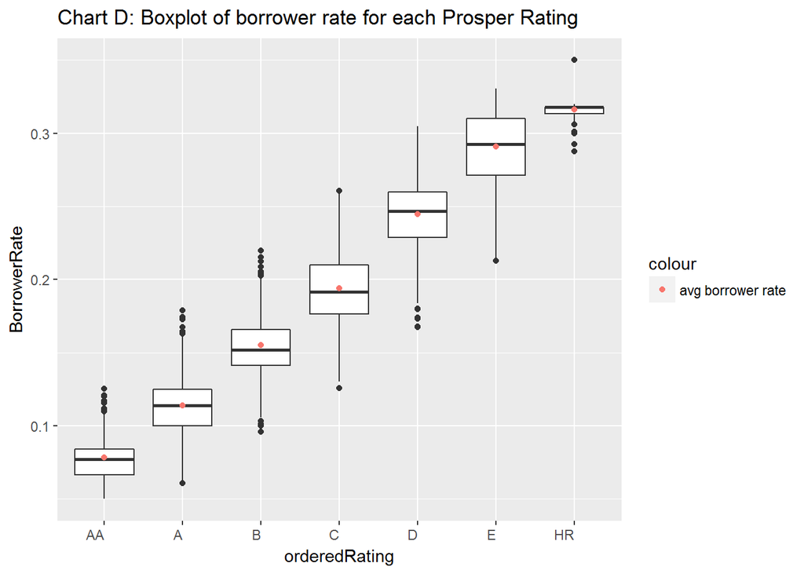

Chart E shows the monthly count of loans by Prosper rating. While it looks like all rating showed increases, ‘C’ showed the highest increase as over 1500 loans of ‘C’ rating was originated in January 2014. Volume for ‘A’- and ‘B’-rated loans also incresed sharply, while others showed much smaller increases.

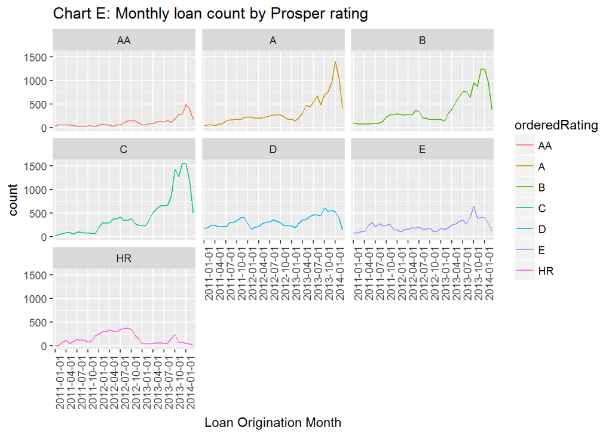

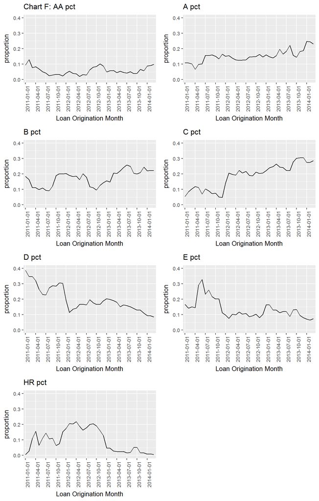

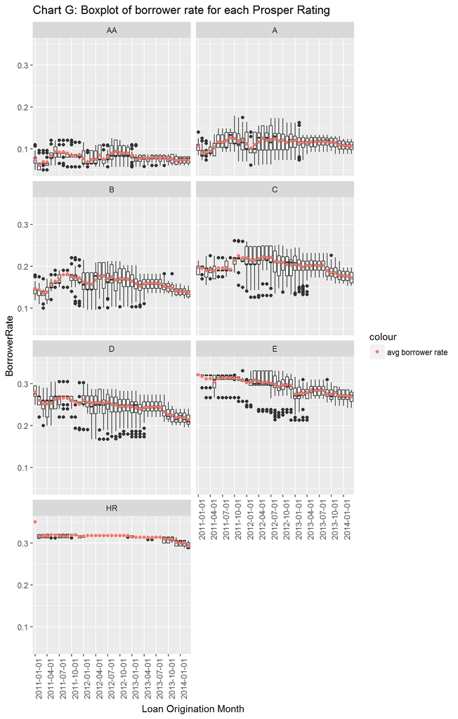

#### Credit score versus borrower rate

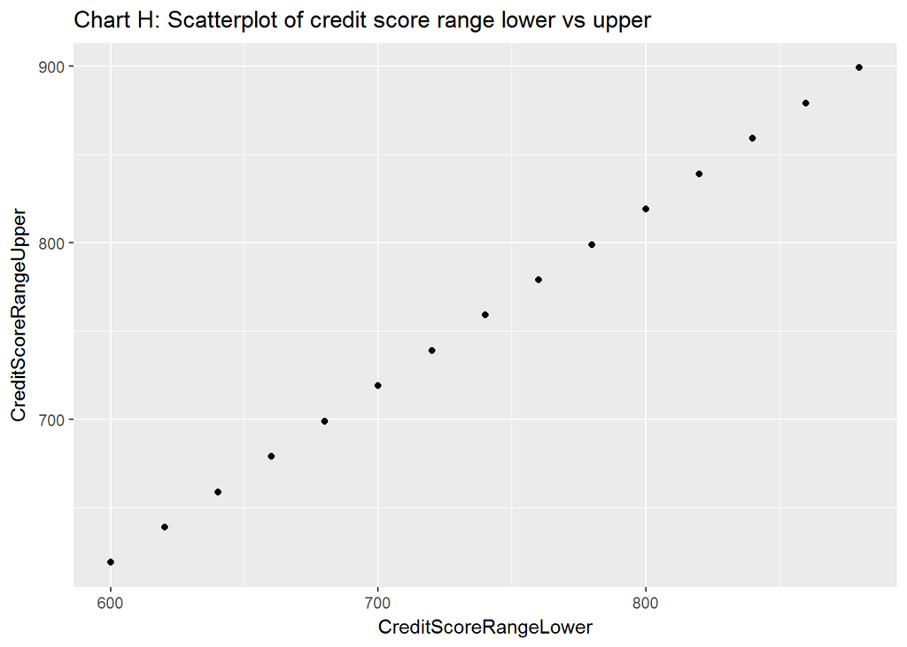

Unlike the borrower rates, credit score did not decline much throughout the period (Chart I).

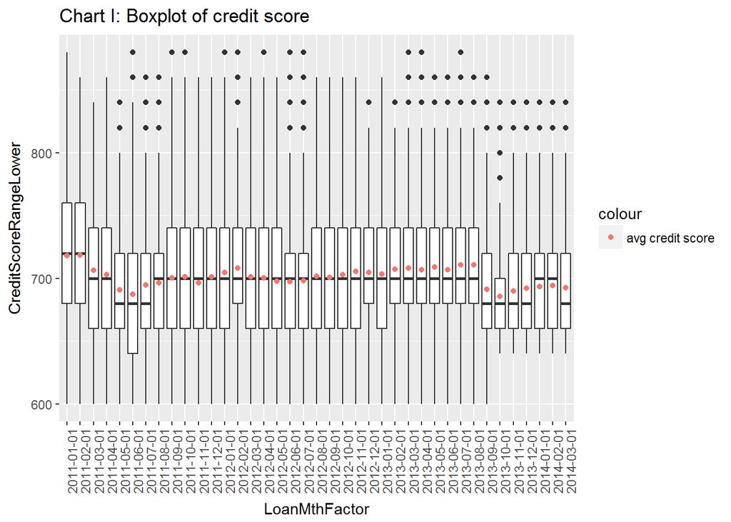

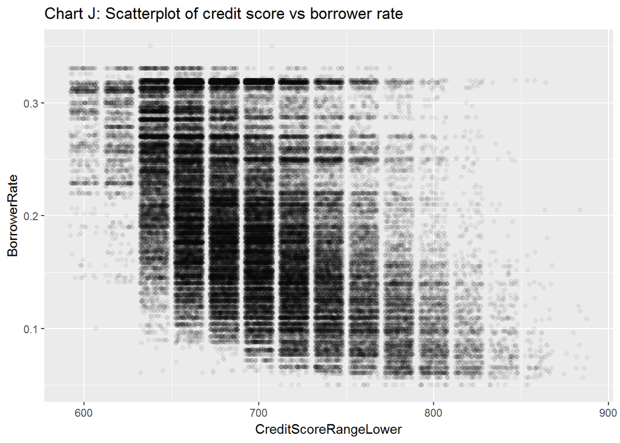

```
##
##  Pearson's product-moment correlation
##
## data:  pdata.post2011$CreditScoreRangeLower and pdata.post2011$BorrowerRate
## t = -152.5, df = 76425, p-value < 2.2e-16
## alternative hypothesis: true correlation is not equal to 0
## 95 percent confidence interval:
##  -0.4884398 -0.4775685
## sample estimates:
##        cor
## -0.4830228
```

```
##
##  Pearson's product-moment correlation
##
## data:  pdata.post2011$CreditScoreRangeLower and log(pdata.post2011$BorrowerRate)
## t = -168.27, df = 76425, p-value < 2.2e-16
## alternative hypothesis: true correlation is not equal to 0
## 95 percent confidence interval:
##  -0.5250821 -0.5147356
## sample estimates:
##        cor
## -0.5199279
```

#### Debt-to-income ratio versus borrower rate

```
##    Min. 1st Qu.  Median    Mean 3rd Qu.    Max.    NA's
##   0.000   0.160   0.230   0.262   0.320  10.010    6367
```

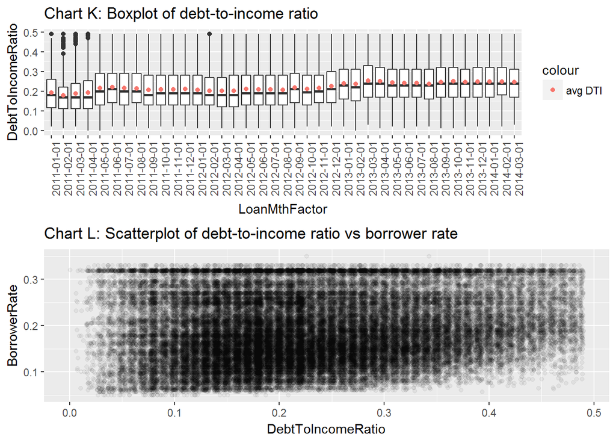

```
##
##  Pearson's product-moment correlation
##
## data:  pdata.post2011$DebtToIncomeRatio and pdata.post2011$BorrowerRate
## t = 35.511, df = 70058, p-value < 2.2e-16
## alternative hypothesis: true correlation is not equal to 0
## 95 percent confidence interval:
##  0.1256896 0.1402374
## sample estimates:
##       cor
## 0.1329706
```

#### IncomeRange/StatedMonthlyIncome versus borrower rate

There were two income variables which I cross-checked to verify: ‘IncomeRange’ and ‘StatedMonthlyIncome’. Chart M shows the cross-check of the two variables. There were some outliers in stated monthly income, such as $1.75 million, which I removed from the chart. Based on the chart, annualized stated monthly income matches the income range, except for a few that fell below $25,000 on the ‘$25,000-49,999’ income range.

```
##    Min. 1st Qu.  Median    Mean 3rd Qu.    Max.
##       0    3500    5000    5999    7167 1750003
```

```
##             $0      $1-24,999      $100,000+ $25,000-49,999 $50,000-74,999
##             33           4007          14070          21428          23099
## $75,000-99,999  Not displayed   Not employed
##          13209              0            581
```

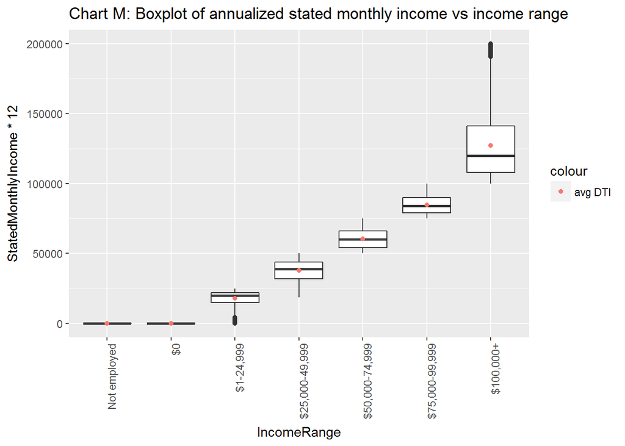

Since stated monthly income provides more information than the income range, I used that to compare to borrower rate. Chart N shows that the monthly income has risen from $4500 in summer of 2011 to $5700 in March 2014.

```
## pdata.post2011$LoanMthFactor: 2011-01-01
##    Min. 1st Qu.  Median    Mean 3rd Qu.    Max.
##       0    3523    5117    6073    7500   50000
## --------------------------------------------------------
## pdata.post2011$LoanMthFactor: 2011-02-01
##    Min. 1st Qu.  Median    Mean 3rd Qu.    Max.
##       0    3333    5000    6227    7500  100000
## --------------------------------------------------------
## pdata.post2011$LoanMthFactor: 2011-03-01
##    Min. 1st Qu.  Median    Mean 3rd Qu.    Max.
##       0    3167    4583    5449    6667   50000
## --------------------------------------------------------
## pdata.post2011$LoanMthFactor: 2011-04-01
##    Min. 1st Qu.  Median    Mean 3rd Qu.    Max.
##       0    3167    4691    6728    7083  466667
## --------------------------------------------------------
## pdata.post2011$LoanMthFactor: 2011-05-01
##    Min. 1st Qu.  Median    Mean 3rd Qu.    Max.
##       0    2917    4458    5797    6500  483333
## --------------------------------------------------------
## pdata.post2011$LoanMthFactor: 2011-06-01
##    Min. 1st Qu.  Median    Mean 3rd Qu.    Max.
##       0    3000    4417    5231    6453   48205
## --------------------------------------------------------
## pdata.post2011$LoanMthFactor: 2011-07-01
##    Min. 1st Qu.  Median    Mean 3rd Qu.    Max.
##       0    3033    4500    5431    6500   79167
## --------------------------------------------------------
## pdata.post2011$LoanMthFactor: 2011-08-01
##    Min. 1st Qu.  Median    Mean 3rd Qu.    Max.
##       0    3164    4583    5495    6667   66667
## --------------------------------------------------------
## pdata.post2011$LoanMthFactor: 2011-09-01
##    Min. 1st Qu.  Median    Mean 3rd Qu.    Max.
##       0    3133    4583    5613    6833   53333
## --------------------------------------------------------
## pdata.post2011$LoanMthFactor: 2011-10-01
##    Min. 1st Qu.  Median    Mean 3rd Qu.    Max.
##       0    3183    4750    5762    7083   75000
## --------------------------------------------------------
```

[output cut: 100 more lines]

```
## pdata.post2011$LoanMthFactor: 2013-12-01
##    Min. 1st Qu.  Median    Mean 3rd Qu.    Max.
##   383.3  3833.3  5416.7  6394.8  7700.0 75000.0
## --------------------------------------------------------
## pdata.post2011$LoanMthFactor: 2014-01-01
##    Min. 1st Qu.  Median    Mean 3rd Qu.    Max.
##      10    3833    5333    6293    7500  158333
## --------------------------------------------------------
## pdata.post2011$LoanMthFactor: 2014-02-01
##    Min. 1st Qu.  Median    Mean 3rd Qu.    Max.
##   416.7  3833.3  5416.7  6332.5  7750.0 70833.3
## --------------------------------------------------------
## pdata.post2011$LoanMthFactor: 2014-03-01
##    Min. 1st Qu.  Median    Mean 3rd Qu.    Max.
##   772.5  4000.0  5708.3  6485.5  7916.7 41666.7
```

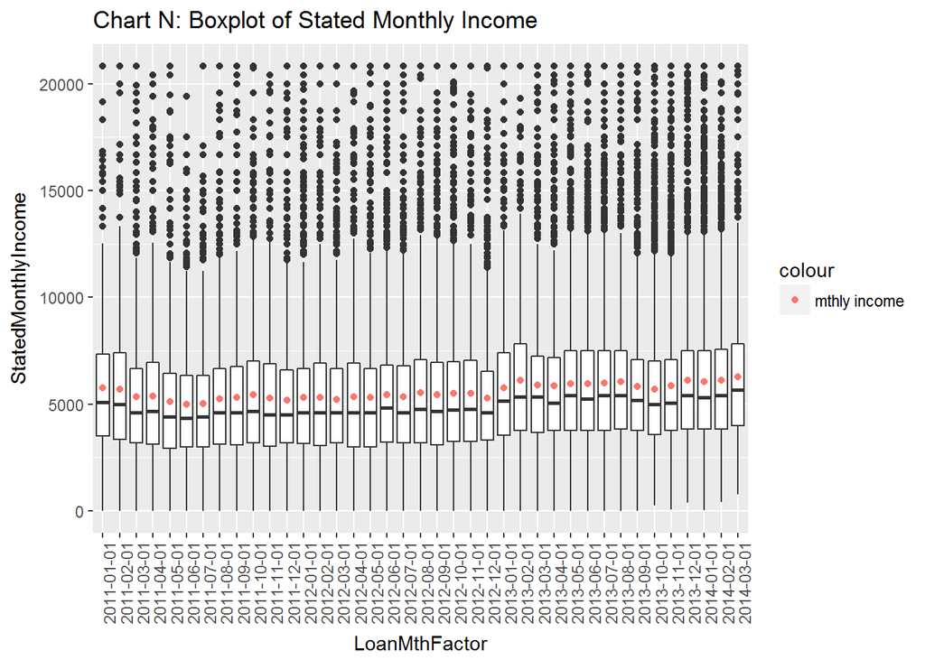

Chart O shows that the relationship between the stated monthly income and borrower rate was a little fuzzy. Correlation of the two variables were -0.09.

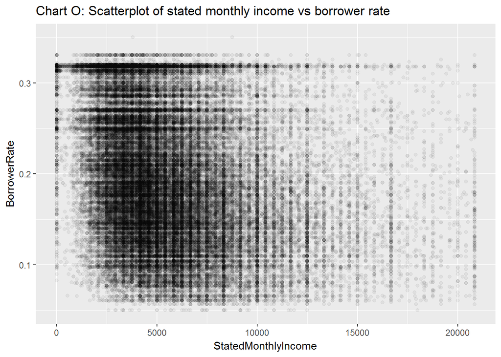

```
##
##  Pearson's product-moment correlation
##
## data:  pdata.post2011$StatedMonthlyIncome and pdata.post2011$BorrowerRate
## t = -25.911, df = 76425, p-value < 2.2e-16
## alternative hypothesis: true correlation is not equal to 0
## 95 percent confidence interval:
##  -0.1003432 -0.0862873
## sample estimates:
##         cor
## -0.09331988
```

#### Income verifiable versus borrower rate

Next, I observed the IncomeVerifiable column. There were 70020 borrowers with verifiable income versus 6407 with non-verfiable income. Chart P shows that the borrower with verifiable income has lower borrower rates. Median borrower rates with verifiable income is 0.18 while median rates for those that cannot be verified is 0.23.

```
## False  True
##  6407 70020
```

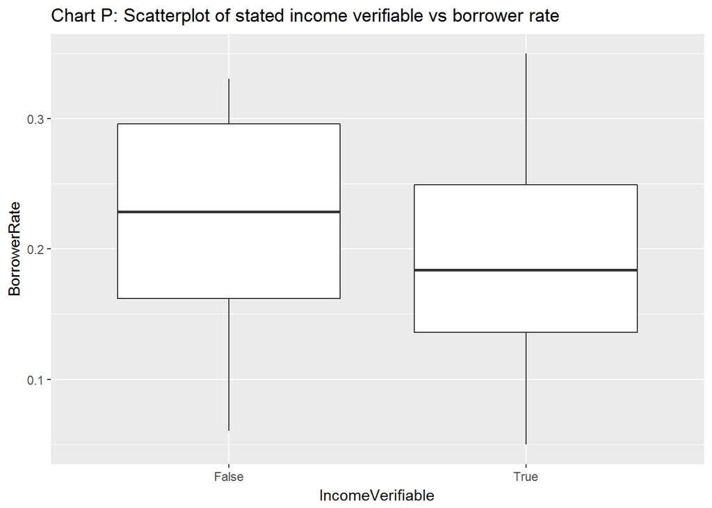

#### Employment status versus borrower rate

Chart Q shows that unemployed borrowers have higher borrower rates than others. There were 65083 ‘Employed’ borrowers and another 2731 borrowers with ‘Full-time’ employment status. Meanwhile, 581 were ‘Not Employed’. Other types include ‘Self-employed’ (4098 borrowers), ‘Retired’ (171), ‘Part-time’ (61) and ‘Other’ (3702).

Median interest rates was highest at 0.28 for unemployed borrowers while those flagged as ‘Employed’ was lowest at 0.18. The median rate for ‘Not employed’ looks to be significantly higher than the rest.

```
##                    Employed     Full-time Not available  Not employed
##             0         65083          2731             0           581
##         Other     Part-time       Retired Self-employed
##          3702            61           171          4098
```

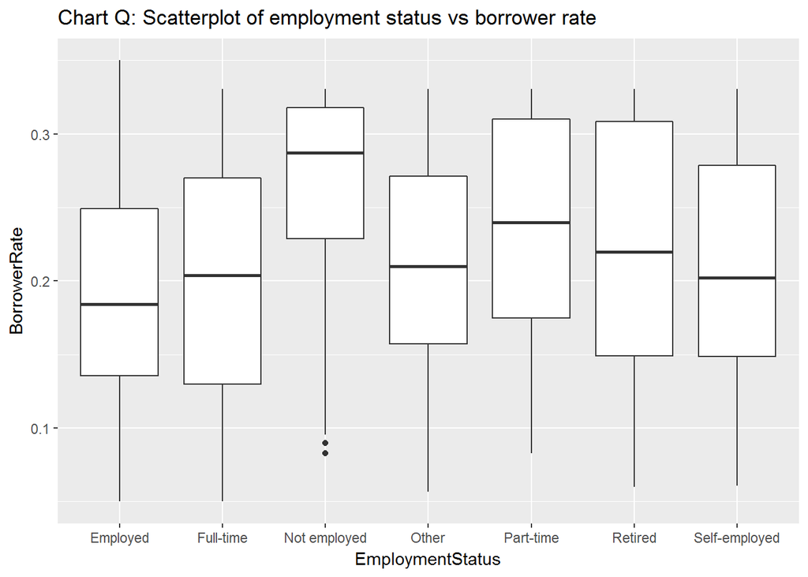

#### Employment status duration versus borrower rate

The median EmploymentStatusDuration was 76 with the min of 0 and max of 755. EmploymentStatusDuration does not seem to have much correlation to borrower rates as seen on Chart R, thus I will not use it in the predictive model.

```
##    Min. 1st Qu.  Median    Mean 3rd Qu.    Max.    NA's
##       0      31      76     105     151     755      12
```

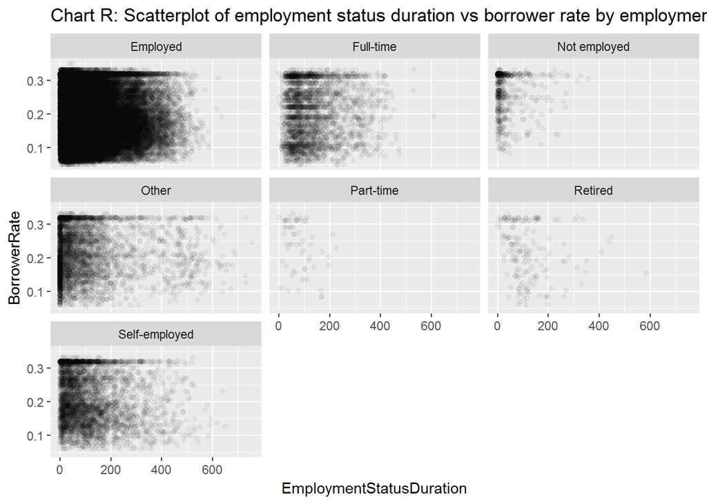

#### Homeownership versus borrower rate

40440 borrowers, or around around 53% of the total, were homeowners compared to 35987 non-homeowners. Homeowner borrowers had lower borrower rates than non-homeowners (Chart S). Median rates for homeowners were 0.17 while it was 0.20 for non-homeowners.

```
## False  True
## 35987 40440
```

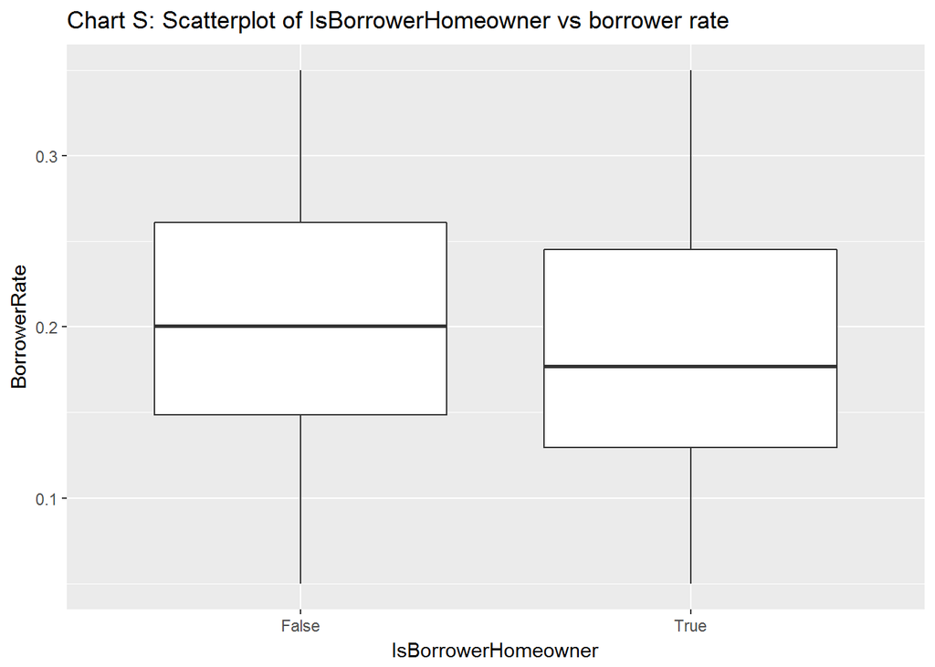

Out of curiosity, I plotted the histogram of Prosper rating by homeownership. While distribution for homeownership type are quite different. Non-homeowners have a bell-curve shape with the peak at ‘C’ rating. Meanwhile, larger proportions of homeowners are in higher quality ratings (‘AA’, ‘A’ and ‘B’). This was expected because homeowners are expected to have higher financial stability than non-homeowners.

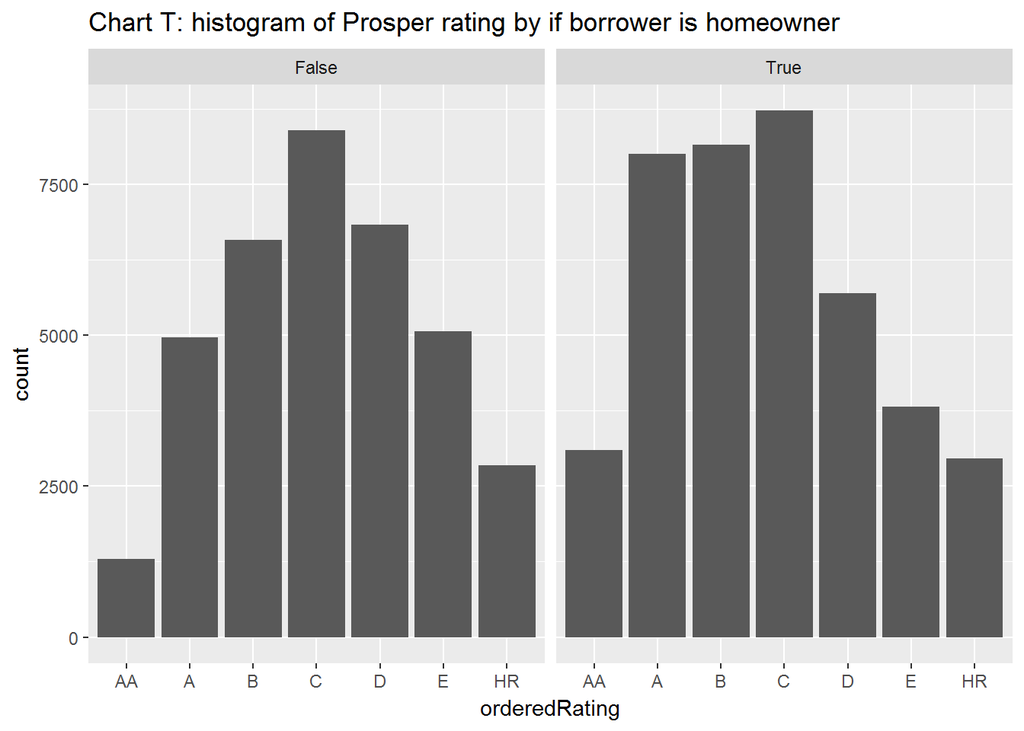

```r
ggplot(data=pdata.post2011, aes(x=orderedRating)) +
  geom_histogram(stat='count') +
  facet_wrap(~IsBorrowerHomeowner) +
  ggtitle('Chart T: histogram of Prosper rating by if borrower is homeowner')
```

#### Term versus borrower rate

The most popular loan term was 3-year with 50629 borrrowers (66%), while there were 24197 5-year loans (32%) and 1601 1-year loans (2%). Lending rates for shorter-term loans should be lower than longer-term loans. Chart U shows that 1-year loans had lowest median rates at 0.14, while 3-year and 5-year were very close at 0.19.

```
##    12    36    60
##  1601 50629 24197
```

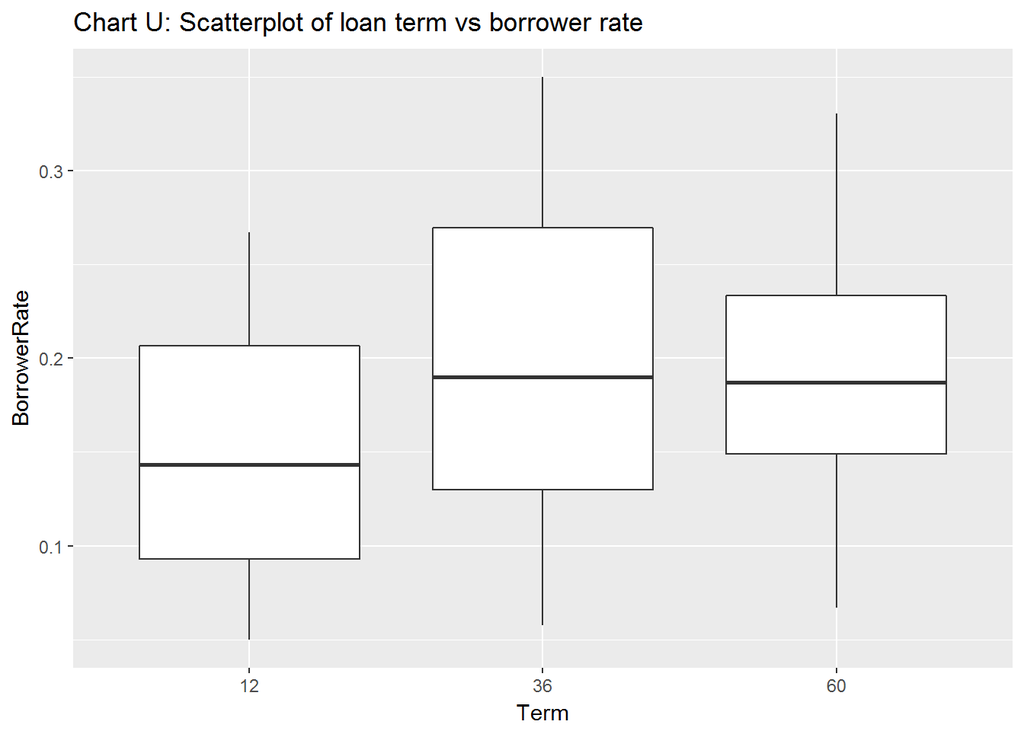

#### predictive model of borrower rate

I used some of the variables analyzed above to come up with a predictive model of borrower rate. The final predictive model is:

lm(formula = BorrowerRate ~ CreditScoreRangeLower + DebtToIncomeRatio + StatedMonthlyIncome + IncomeVerifiable + EmploymentStatus + IsBorrowerHomeowner + Term, data = pdata.post2011)

R-square of the regression was 0.29, which was fairly disppointing. Variable-wise, IncomeVerifiableTrue was not statistically significant as well as some of the types in EmploymentStatus.

```
##
## Calls:
## m1: lm(formula = BorrowerRate ~ CreditScoreRangeLower, data = pdata.post2011)
## m2: lm(formula = BorrowerRate ~ CreditScoreRangeLower + DebtToIncomeRatio,
##     data = pdata.post2011)
## m3: lm(formula = BorrowerRate ~ CreditScoreRangeLower + DebtToIncomeRatio +
##     StatedMonthlyIncome, data = pdata.post2011)
## m4: lm(formula = BorrowerRate ~ CreditScoreRangeLower + DebtToIncomeRatio +
##     StatedMonthlyIncome + IncomeVerifiable, data = pdata.post2011)
## m5: lm(formula = BorrowerRate ~ CreditScoreRangeLower + DebtToIncomeRatio +
##     StatedMonthlyIncome + IncomeVerifiable + EmploymentStatus,
##     data = pdata.post2011)
## m6: lm(formula = BorrowerRate ~ CreditScoreRangeLower + DebtToIncomeRatio +
##     StatedMonthlyIncome + IncomeVerifiable + EmploymentStatus +
##     IsBorrowerHomeowner, data = pdata.post2011)
## m7: lm(formula = BorrowerRate ~ CreditScoreRangeLower + DebtToIncomeRatio +
##     StatedMonthlyIncome + IncomeVerifiable + EmploymentStatus +
##     IsBorrowerHomeowner + Term, data = pdata.post2011)
##
## =====================================================================================================================
##                                     m1          m2          m3          m4          m5          m6          m7
## ---------------------------------------------------------------------------------------------------------------------
##   (Intercept)                    0.726***    0.731***    0.729***    0.726***    0.703***    0.713***    0.675***
##                                 (0.003)     (0.004)     (0.003)     (0.009)     (0.025)     (0.025)     (0.025)
##   CreditScoreRangeLower         -0.001***   -0.001***   -0.001***   -0.001***   -0.001***   -0.001***   -0.001***
##                                 (0.000)     (0.000)     (0.000)     (0.000)     (0.000)     (0.000)     (0.000)
##   DebtToIncomeRatio                          0.028***    0.026***    0.026***    0.025***    0.025***    0.025***
##                                             (0.001)     (0.001)     (0.001)     (0.001)     (0.001)     (0.001)
##   StatedMonthlyIncome                                   -0.000***   -0.000***   -0.000***   -0.000***   -0.000***
##                                                         (0.000)     (0.000)     (0.000)     (0.000)     (0.000)
##   IncomeVerifiableTrue                                               0.004       0.025       0.026       0.028
##                                                                     (0.009)     (0.025)     (0.025)     (0.025)
##   EmploymentStatusFull-time                                                     -0.000      -0.001       0.001
##                                                                                 (0.001)     (0.001)     (0.001)
##   EmploymentStatusOther                                                          0.011***    0.011***    0.011***
##                                                                                 (0.001)     (0.001)     (0.001)
##   EmploymentStatusPart-time                                                      0.008       0.008       0.008
##                                                                                 (0.009)     (0.009)     (0.009)
##   EmploymentStatusRetired                                                        0.011*      0.011*      0.011*
##                                                                                 (0.005)     (0.005)     (0.005)
##   EmploymentStatusSelf-employed                                                  0.026       0.026       0.028
##                                                                                 (0.026)     (0.026)     (0.026)
##   IsBorrowerHomeownerTrue                                                                    0.007***    0.006***
##                                                                                             (0.000)     (0.000)
##   Term36                                                                                                 0.033***
##                                                                                                         (0.002)
##   Term60                                                                                                 0.038***
##                                                                                                         (0.002)
## ---------------------------------------------------------------------------------------------------------------------
##   R-squared                           0.233       0.271       0.279       0.279       0.280       0.282       0.288
##   adj. R-squared                      0.233       0.271       0.279       0.279       0.280       0.282       0.288
##   sigma                               0.063       0.061       0.061       0.061       0.061       0.060       0.060
##   F                               23256.879   13028.837    9044.501    6783.337    3031.441    2754.693    2359.699
##   p                                   0.000       0.000       0.000       0.000       0.000       0.000       0.000
##   Log-likelihood                 102674.414   96632.324   97022.382   97022.466   97077.052   97172.065   97447.453
##   Deviance                          304.707     259.997     257.118     257.118     256.717     256.022     254.017
##   AIC                           -205342.828 -193256.648 -194034.764 -194032.933 -194132.105 -194320.129 -194866.907
##   BIC                           -205315.095 -193220.020 -193988.979 -193977.990 -194031.377 -194210.244 -194738.707
##   N                               76427       70060       70060       70060       70060       70060       70060
## =====================================================================================================================
```

```
##
## Call:
## lm(formula = BorrowerRate ~ CreditScoreRangeLower + DebtToIncomeRatio +
##     StatedMonthlyIncome + IncomeVerifiable + EmploymentStatus +
##     IsBorrowerHomeowner + Term, data = pdata.post2011)
##
## Coefficients:
##                   (Intercept)          CreditScoreRangeLower
##                     6.753e-01                     -7.833e-04
##             DebtToIncomeRatio            StatedMonthlyIncome
##                     2.494e-02                     -1.282e-06
##          IncomeVerifiableTrue      EmploymentStatusFull-time
##                     2.762e-02                      7.089e-04
##         EmploymentStatusOther      EmploymentStatusPart-time
##                     1.128e-02                      8.426e-03
##       EmploymentStatusRetired  EmploymentStatusSelf-employed
##                     1.149e-02                      2.818e-02
##       IsBorrowerHomeownerTrue                         Term36
##                     5.958e-03                      3.315e-02
##                        Term60
##                     3.800e-02
```

Given that the borrower rates has gotten lower over time period, it is possible that Prosper did not use same model to price rates through this time period. Instead, their lending rate model may have gone through many upgrades. Out of curiosity, I added month-year as a new independent variable to test whether this improves the predictive model. R-square improves to 0.46 adding the month-year as an independent variable.

```
##
## Calls:
## m8: lm(formula = BorrowerRate ~ CreditScoreRangeLower + DebtToIncomeRatio +
##     StatedMonthlyIncome + IncomeVerifiable + EmploymentStatus +
##     IsBorrowerHomeowner + Term + LoanMthFactor, data = pdata.post2011)
##
## =============================================
##   (Intercept)                    0.782***
##                                 (0.022)
##   CreditScoreRangeLower         -0.001***
##                                 (0.000)
##   DebtToIncomeRatio              0.026***
##                                 (0.001)
##   StatedMonthlyIncome           -0.000***
##                                 (0.000)
##   IncomeVerifiableTrue          -0.012
##                                 (0.022)
##   EmploymentStatusFull-time     -0.030***
##                                 (0.001)
##   EmploymentStatusOther          0.015***
##                                 (0.001)
##   EmploymentStatusPart-time     -0.027***
##                                 (0.008)
##   EmploymentStatusRetired       -0.018***
##                                 (0.004)
##   EmploymentStatusSelf-employed -0.002
##                                 (0.023)
##   IsBorrowerHomeownerTrue        0.006***
##                                 (0.000)
##   Term36                         0.058***
##                                 (0.001)
##   Term60                         0.068***
##                                 (0.001)
##   LoanMthFactor2011-02-01       -0.014***
##                                 (0.003)
##   LoanMthFactor2011-03-01       -0.010**
##                                 (0.003)
##   LoanMthFactor2011-04-01       -0.008*
##                                 (0.003)
##   LoanMthFactor2011-05-01       -0.014***
```

[output cut: 66 more lines]

```
##                                 (0.003)
##   LoanMthFactor2014-03-01       -0.096***
##                                 (0.003)
## ---------------------------------------------
##   R-squared                           0.456
##   adj. R-squared                      0.456
##   sigma                               0.053
##   F                                1173.593
##   p                                   0.000
##   Log-likelihood                 106879.972
##   Deviance                          194.053
##   AIC                           -213655.944
##   BIC                           -213179.775
##   N                               70060
## =============================================
```

### Final plot and summary

#### Plot One

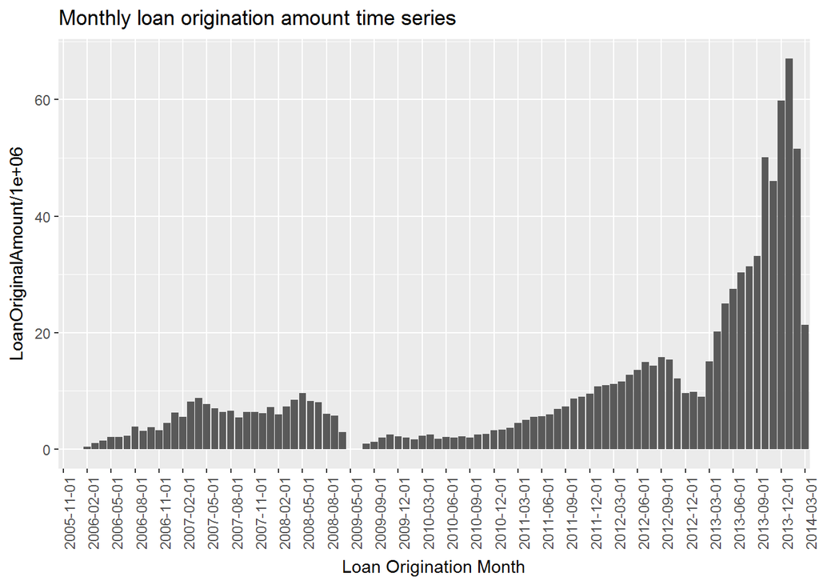

#### Description One

This bar chart shows the monthly loan volume for Prosper. It has stalled during the financial crisis after 2008, but volume has picked up drastically from 2009 to 2014.

#### Plot Two

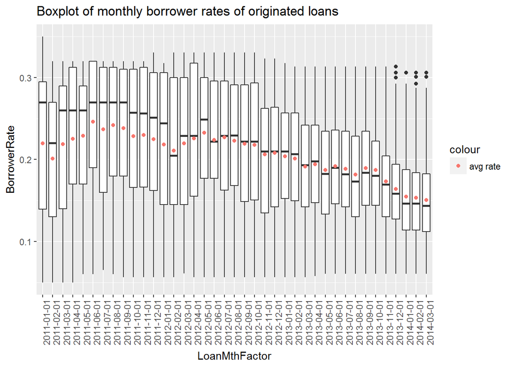

#### Description Two

Borrower rates has declined from mid-2011 to early-2014 while the interquartile range has shrunk.

#### Plot Three

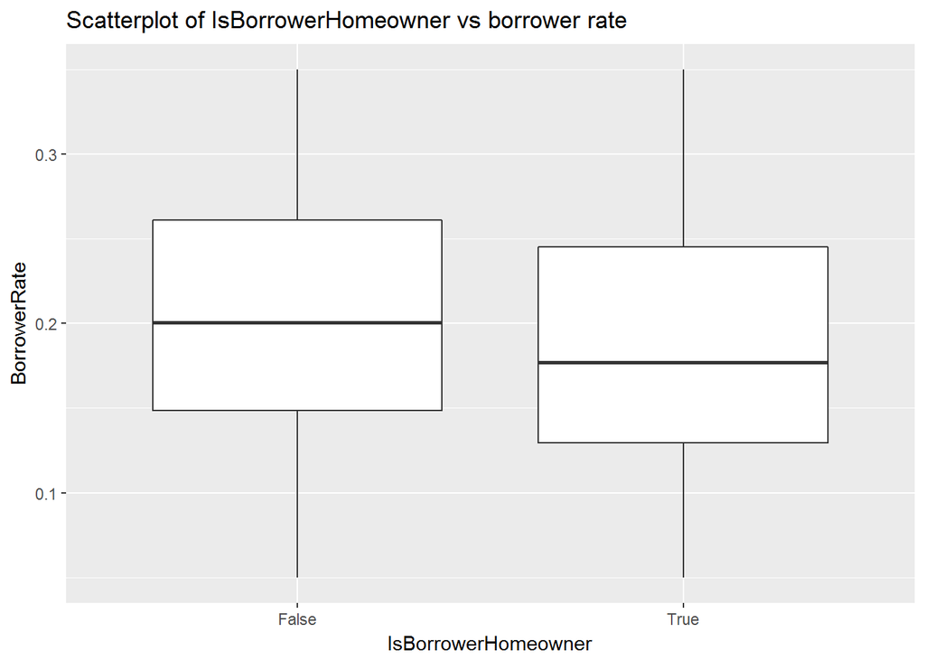

#### Description Three

Homeowner borrowers have lower median rates than non-homeowner borrowers.

### Reflection

Prosper data set contains data of over 110,000 loans originated from November 2005 to March 2014. Lending activity halted in 2008 during the financial crisis and restated in late 2009 and has seen strong growth since then. Due to the change in Prosper’s lending practice from auctioned based to fixed-pricing model in December 2010, I used the data from 2011 and beyond for analyzing the borrower loan rate to other independent variables.

There were negative relationship between credit score and borrower rate as expected. Debt-to-income ratio showed a slight positive correlation to borrower rate while income showed a slight negative correlation. Borrowers who’s income were verifiable, who were employed or who were homeowners tended to lower interest rates than their counterparts.

Unfortunately, the r-square of the predictive model was fairly low at 0.28. One of the reason may be because Prosper may have continually updated their lending rate model throughout the time period. This means a borrower with certain characteristic would have one interst rate in January 2011, but the borrower with same characterisctic would have gotten a different rate in January 2014. If this is a case, there is no consistency in the data that we are trying to regress on.

Furthermore, Prosper likely would have had more variables, such as delinquency history, to come up with their interest rate model than they had provided. These additional data would help improve the predictive model.

While the result of the predictive model was fairly disappointing, I learned a lot about Prosper, R and statistics working on this project.